# Démarrage rapide avec nemeton

Pascal Obstétar

2026-01-24

# Introduction

Le package `nemeton` implémente la méthode Nemeton pour l’analyse systémique de territoires forestiers. Il fournit des outils pour :

- Calculer des indicateurs biophysiques multi-famille (carbone, eau, sols, paysage, etc.)
- Normaliser les valeurs d’indicateurs selon plusieurs méthodes
- Créer des indices composites pour une évaluation holistique
- Visualiser les résultats avec des cartes et graphiques

Cette vignette démontre le workflow complet avec le jeu de données `massif_demo`.

# Installation

```r
# Depuis GitHub
remotes::install_github("pobsteta/nemeton")
```

```r
library(nemeton)
library(ggplot2)
```

# Charger les données de démonstration

Le package inclut un jeu de données synthétique (`massif_demo`) représentant une zone de 5km × 5km avec 20 parcelles forestières.

```r
# Charger les parcelles forestières
data(massif_demo_units)

# Inspecter les parcelles
print(massif_demo_units)
```

```
#> Simple feature collection with 20 features and 5 fields
#> Geometry type: POLYGON
#> Dimension:     XY
#> Bounding box:  xmin: 698041.8 ymin: 6499215 xmax: 702793.8 ymax: 6504159
#> Projected CRS: RGF93 v1 / Lambert-93
#> First 10 features:
#>    parcel_id      forest_type age_class   management surface_ha
#> 1        P01     Futaie mixte    Mature        Mixte   4.989211
#> 2        P02 Futaie résineuse     Moyen   Production   5.867935
#> 3        P03  Futaie feuillue  Surannée Conservation   6.557777
#> 4        P04  Futaie feuillue  Surannée   Production   9.989553
#> 5        P05 Futaie résineuse     Moyen   Production   5.906395
#> 6        P06 Futaie résineuse    Mature   Production   1.048296
#> 7        P07  Futaie feuillue    Mature        Mixte  17.079363
#> 8        P08  Futaie feuillue    Mature   Production  11.414577
#> 9        P09     Futaie mixte     Moyen   Production  16.105209
#> 10       P10          Taillis  Surannée   Production  10.733433
#>                          geometry
#> 1  POLYGON ((698299.9 6499928,...
#> 2  POLYGON ((701702.2 6500418,...
#> 3  POLYGON ((702240.4 6500270,...
#> 4  POLYGON ((700641.3 6504129,...
#> 5  POLYGON ((699268.2 6500307,...
#> 6  POLYGON ((699943.5 6499421,...
#> 7  POLYGON ((698500.5 6499360,...
#> 8  POLYGON ((699061.9 6499649,...
#> 9  POLYGON ((702258.5 6500666,...
#> 10 POLYGON ((699897.1 6500739,...
```

```r
# Statistiques sommaires
cat("\nSurface totale:", sum(massif_demo_units$surface_ha), "ha\n")
```

```
#>
#> Surface totale: 136.0225 ha
```

```r
table(massif_demo_units$forest_type)
```

```
#>
#>  Futaie feuillue     Futaie mixte Futaie résineuse          Taillis
#>               11                2                4                3
```

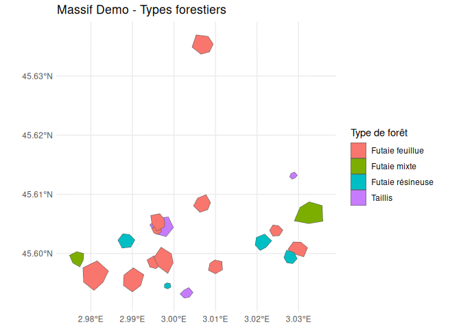

Parcelles forestières par type

```r
ggplot(massif_demo_units) +
  geom_sf(aes(fill = forest_type)) +
  theme_minimal() +
  labs(
    title = "Massif Demo - Types forestiers",
    fill = "Type de forêt"
  )
```

# Charger les couches spatiales

Utilisez `massif_demo_layers()` pour charger tous les rasters et vecteurs associés :

```r
layers <- massif_demo_layers()
print(layers)
```

```
#>
#> ── nemeton_layers object ───────
#>
#> ── Rasters (4) ──
#>
#> • biomass : massif_demo_biomass.tif [not loaded]
#> • dem : massif_demo_dem.tif [not loaded]
#> • landcover : massif_demo_landcover.tif [not loaded]
#> • species_richness : massif_demo_species_richness.tif [not loaded]
#>
#> ── Vectors (2) ──
#>
#> • roads : massif_demo_roads.gpkg [not loaded]
#> • water : massif_demo_water.gpkg [not loaded]
```

Le jeu de données inclut : - **Rasters** : biomasse, MNT, occupation du sol, richesse spécifique - **Vecteurs** : réseau routier, cours d’eau

# Calculer les indicateurs

## Indicateurs individuels

```r
# Carbone (via NDVI)
carbon <- nemeton_compute(
  massif_demo_units,
  layers,
  indicators = "carbon_ndvi"
)

# Eau (TWI - Topographic Wetness Index)
water <- nemeton_compute(
  massif_demo_units,
  layers,
  indicators = "water_twi"
)

# Afficher les résultats
head(carbon[, c("parcel_id", "forest_type", "carbon_ndvi")])
```

```
#> Simple feature collection with 6 features and 3 fields
#> Geometry type: POLYGON
#> Dimension:     XY
#> Bounding box:  xmin: 698041.8 ymin: 6499388 xmax: 702507.7 ymax: 6504159
#> Projected CRS: RGF93 v1 / Lambert-93
#>   parcel_id      forest_type carbon_ndvi                       geometry
#> 1       P01     Futaie mixte          NA POLYGON ((698299.9 6499928,...
#> 2       P02 Futaie résineuse          NA POLYGON ((701702.2 6500418,...
#> 3       P03  Futaie feuillue          NA POLYGON ((702240.4 6500270,...
#> 4       P04  Futaie feuillue          NA POLYGON ((700641.3 6504129,...
#> 5       P05 Futaie résineuse          NA POLYGON ((699268.2 6500307,...
#> 6       P06 Futaie résineuse          NA POLYGON ((699943.5 6499421,...
```

## Indicateurs multiples simultanés

```r
# Calculer 3 indicateurs en une fois
results <- nemeton_compute(
  massif_demo_units,
  layers,
  indicators = c("carbon_ndvi", "water_twi", "landscape_fragmentation")
)

# Vue d'ensemble
summary(results[, c("carbon_ndvi", "water_twi", "landscape_fragmentation")])
```

```
#>   carbon_ndvi    water_twi     landscape_fragmentation          geometry
#>  Min.   : NA   Min.   :4.597   Min.   :1               POLYGON      :20
#>  1st Qu.: NA   1st Qu.:4.657   1st Qu.:1               epsg:2154    : 0
#>  Median : NA   Median :4.692   Median :1               +proj=lcc ...: 0
#>  Mean   :NaN   Mean   :4.736   Mean   :1
#>  3rd Qu.: NA   3rd Qu.:4.776   3rd Qu.:1
#>  Max.   : NA   Max.   :5.056   Max.   :1
#>  NA's   :20
```

# Normalisation

Normalisez les indicateurs pour les rendre comparables (échelle 0-100) :

```r
# Normalisation min-max
normalized <- normalize_indicators(
  results,
  indicators = c("carbon_ndvi", "water_twi", "landscape_fragmentation"),
  method = "minmax"
)

# Comparer avant/après
cat("\nAvant normalisation (carbone NDVI):\n")
```

```
#>
#> Avant normalisation (carbone NDVI):
```

```r
summary(results$carbon_ndvi)
```

```
#>    Min. 1st Qu.  Median    Mean 3rd Qu.    Max.    NA's
#>      NA      NA      NA     NaN      NA      NA      20
```

```r
cat("\nAprès normalisation (carbone NDVI):\n")
```

```
#>
#> Après normalisation (carbone NDVI):
```

```r
summary(normalized$carbon_ndvi_norm)
```

```
#>    Min. 1st Qu.  Median    Mean 3rd Qu.    Max.    NA's
#>      NA      NA      NA     NaN      NA      NA      20
```

## Méthodes de normalisation

```r
# z-score (distribution normale centrée-réduite)
norm_zscore <- normalize_indicators(
  results,
  indicators = "carbon_ndvi",
  method = "zscore"
)

# Quantiles (distribution uniforme)
norm_quantile <- normalize_indicators(
  results,
  indicators = "carbon_ndvi",
  method = "quantile"
)
```

# Agrégation en indices composites

Combinez plusieurs indicateurs en un indice unique :

```r
# Indice composite avec poids égaux
composite <- create_composite_index(
  normalized,
  indicators = c("carbon_ndvi_norm", "water_twi_norm", "landscape_fragmentation_norm"),
  name = "ecosystem_health"
)

# Afficher les résultats
head(composite[, c("parcel_id", "forest_type", "ecosystem_health")])
```

```
#> Simple feature collection with 6 features and 3 fields
#> Geometry type: POLYGON
#> Dimension:     XY
#> Bounding box:  xmin: 698041.8 ymin: 6499388 xmax: 702507.7 ymax: 6504159
#> Projected CRS: RGF93 v1 / Lambert-93
#>   parcel_id      forest_type ecosystem_health                       geometry
#> 1       P01     Futaie mixte         28.68670 POLYGON ((698299.9 6499928,...
#> 2       P02 Futaie résineuse         53.62512 POLYGON ((701702.2 6500418,...
#> 3       P03  Futaie feuillue         35.25483 POLYGON ((702240.4 6500270,...
#> 4       P04  Futaie feuillue         60.52002 POLYGON ((700641.3 6504129,...
#> 5       P05 Futaie résineuse         45.08368 POLYGON ((699268.2 6500307,...
#> 6       P06 Futaie résineuse         29.32097 POLYGON ((699943.5 6499421,...
```

## Agrégation pondérée

```r
# Poids personnalisés (carbone 50%, paysage 30%, eau 20%)
composite_weighted <- create_composite_index(
  normalized,
  indicators = c("carbon_ndvi_norm", "landscape_fragmentation_norm", "water_twi_norm"),
  weights = c(0.5, 0.3, 0.2),
  name = "conservation_index"
)
```

## Méthodes d’agrégation

```r
# Moyenne géométrique (effets multiplicatifs)
composite_geom <- create_composite_index(
  normalized,
  indicators = c("carbon_ndvi_norm", "water_twi_norm"),
  aggregation = "geometric_mean",
  name = "water_carbon_index"
)

# Minimum (approche conservatrice, facteur limitant)
composite_min <- create_composite_index(
  normalized,
  indicators = c("carbon_ndvi_norm", "water_twi_norm"),
  aggregation = "min",
  name = "minimum_performance"
)
```

# Visualisation

## Cartes thématiques

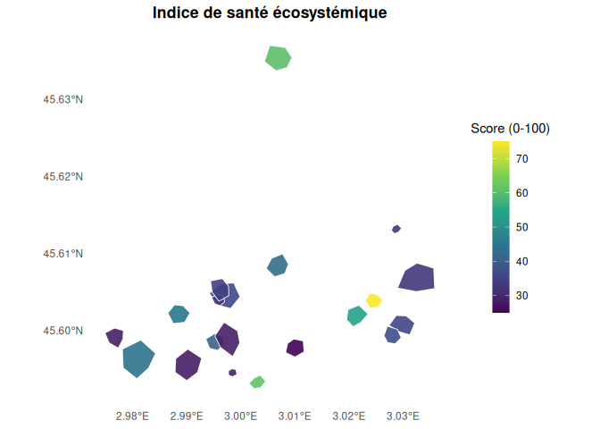

Carte de l’indice de santé écosystémique

```r
plot_indicators_map(
  composite,
  indicators = "ecosystem_health",
  title = "Indice de santé écosystémique",
  legend_title = "Score (0-100)"
)
```

## Cartes multiples (facettes)

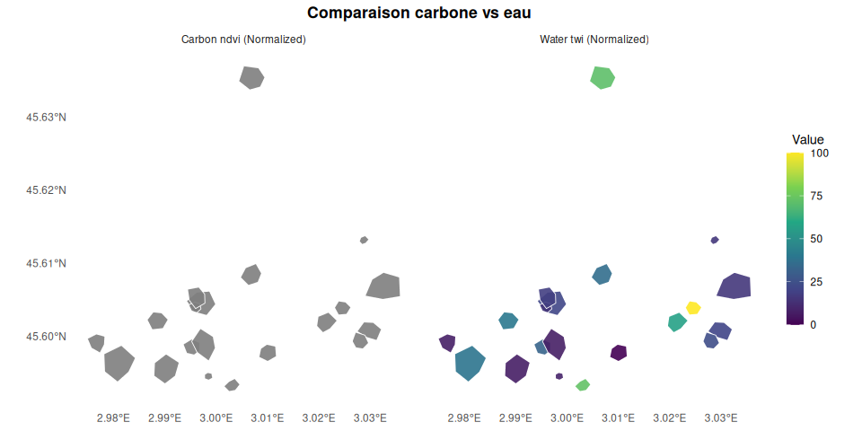

Comparaison carbone vs eau

```r
plot_indicators_map(
  normalized,
  indicators = c("carbon_ndvi_norm", "water_twi_norm"),
  palette = "viridis",
  facet = TRUE,
  ncol = 2,
  title = "Comparaison carbone vs eau"
)
```

## Graphique radar

```r
nemeton_radar(
  normalized,
  unit_id = "P01",
  indicators = c("carbon_ndvi_norm", "water_twi_norm", "landscape_fragmentation_norm"),
  title = "Profil multi-indicateurs - Parcelle P01"
)
```

[figure not shown]

Profil écosystémique - Parcelle P01

# Workflow complet

Voici un exemple de workflow complet de bout en bout :

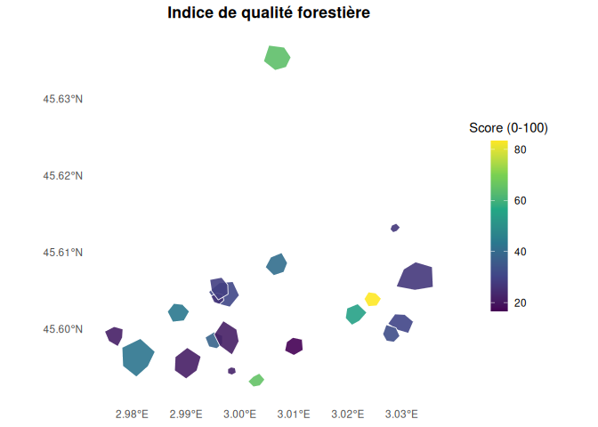

```r
# 1. Charger les données
data(massif_demo_units)
layers <- massif_demo_layers()

# 2. Calculer les indicateurs
results <- nemeton_compute(
  massif_demo_units,
  layers,
  indicators = c(
    "carbon_ndvi", "water_twi", "landscape_fragmentation"
  )
)

# 3. Normaliser (0-100)
normalized <- normalize_indicators(
  results,
  indicators = c(
    "carbon_ndvi", "water_twi", "landscape_fragmentation"
  ),
  method = "minmax"
)

# 4. Créer un indice composite
composite <- create_composite_index(
  normalized,
  indicators = c("carbon_ndvi_norm", "water_twi_norm", "landscape_fragmentation_norm"),
  weights = c(0.4, 0.4, 0.2),
  name = "forest_quality"
)

# 5. Visualiser
plot_indicators_map(
  composite,
  indicators = "forest_quality",
  title = "Indice de qualité forestière",
  legend_title = "Score (0-100)"
)
```

# Analyses avancées

## Inverser un indicateur

Pour les indicateurs où une valeur faible est souhaitable :

```r
# Exemple: inverser un indicateur
# (Utilisé pour les indicateurs où une valeur faible est souhaitable)
normalized_inv <- invert_indicator(
  normalized,
  indicators = "water_twi_norm",
  suffix = "_inv"
)

# L'indicateur inversé
head(normalized_inv[, c("parcel_id", "water_twi_norm", "water_twi_norm_inv")])
```

[output not shown]

## Filtrage et sous-ensembles

```r
# Sélectionner uniquement les futaies feuillues
broadleaf <- normalized[normalized$forest_type == "Futaie feuillue", ]

# Créer un indice spécifique
broadleaf_index <- create_composite_index(
  broadleaf,
  indicators = c("carbon_ndvi_norm", "water_twi_norm"),
  name = "broadleaf_quality"
)
```

# Internationalisation

Le package supporte le français et l’anglais :

```r
# Définir la langue
nemeton_set_language("fr") # Français
# nemeton_set_language("en")  # English

# Les messages d'erreur/information seront dans la langue choisie
```

# Export des résultats

```r
# Export en GeoPackage
sf::st_write(composite, "results/forest_quality.gpkg")

# Export en CSV (sans géométrie)
results_table <- composite |>
  sf::st_drop_geometry()
write.csv(results_table, "results/forest_quality.csv", row.names = FALSE)
```

# Prochaines étapes

- **Analyse temporelle** : `vignette("temporal-analysis_fr")` - Analyse multi-périodes
- **Familles d’indicateurs** : `vignette("indicator-families_fr")` - Système 12 familles
- **Internationalisation** : `vignette("internationalization")` - Système i18n

# Références

- Méthode Nemeton : Développée par Vivre en Forêt
- Documentation complète : `help(package = "nemeton")`
- Site web : https://pobsteta.github.io/nemeton/